| Team Member Name | ID |
| --- | --- |
| Kareem Ayman Farouk | 18P6994 |
| Mohamed Mokhtar Abdelrasoul | 18P7232 |

# Imports

```python
# Basic Machine Libararies.
import pandas as pd
import numpy as np
from math import sqrt

# Data Manipulation Libarires.
from sklearn.model_selection import train_test_split
from sklearn.model_selection import RepeatedStratifiedKFold, cross_validate
from sklearn.preprocessing import MinMaxScaler, StandardScaler
from sklearn.preprocessing import PowerTransformer, QuantileTransformer
from imblearn.over_sampling import RandomOverSampler
from sklearn.pipeline import Pipeline
from sklearn import decomposition, datasets

# Classifiers
from sklearn.neighbors import KNeighborsClassifier
from sklearn.linear_model import LogisticRegression
from sklearn.naive_bayes import GaussianNB
from sklearn.tree import DecisionTreeClassifier
from sklearn.svm import SVC

# Grid Search Libarary.
from sklearn.model_selection import GridSearchCV

# Data Visualization Libararies.
from matplotlib import pyplot
import sklearn.metrics
import matplotlib.pyplot as plt
import seaborn as sns
from IPython.display import display
from sklearn.tree import export_graphviz
from six import StringIO
from IPython.display import Image
import pydotplus
from IPython.display import display
```

```python
# Random Seed is important so that you receive the same output.
np.random.seed(42)

# For warning
import warnings
warnings.filterwarnings('ignore')  # "error", "ignore", "always", "default", "module" or "once"
```

# Optional Installations

```python
#!pip install seaborn
#!pip install imblearn
#!pip install graphviz
```

# Data Reading And Displaying

```python
df = pd.read_csv("data.csv", index_col=0) # Reading the data.
display(df) # Displaying the data read from the .csv file.
```

|  | location | country | gender | age | vis_wuhan | from_wuhan | symptom1 | symptom2 | symptom3 | symptom4 | symptom5 | symptom6 | diff_sym_hos | result |
| --- | --- | --- | --- | --- | --- | --- | --- | --- | --- | --- | --- | --- | --- | --- |
| 0 | 104 | 8 | 1 | 66.0 | 1 | 0 | 14 | 31 | 19 | 12 | 3 | 1 | 8 | 1 |
| 1 | 101 | 8 | 0 | 56.0 | 0 | 1 | 14 | 31 | 19 | 12 | 3 | 1 | 0 | 0 |
| 2 | 137 | 8 | 1 | 46.0 | 0 | 1 | 14 | 31 | 19 | 12 | 3 | 1 | 13 | 0 |
| 3 | 116 | 8 | 0 | 60.0 | 1 | 0 | 14 | 31 | 19 | 12 | 3 | 1 | 0 | 0 |
| 4 | 116 | 8 | 1 | 58.0 | 0 | 0 | 14 | 31 | 19 | 12 | 3 | 1 | 0 | 0 |
| ... | ... | ... | ... | ... | ... | ... | ... | ... | ... | ... | ... | ... | ... | ... |
| 858 | 48 | 3 | 2 | 24.0 | 0 | 0 | 14 | 31 | 19 | 12 | 3 | 1 | 0 | 1 |
| 859 | 0 | 0 | 2 | 35.0 | 0 | 0 | 14 | 31 | 19 | 12 | 3 | 1 | 0 | 0 |
| 860 | 3 | 1 | 1 | 49.4 | 0 | 0 | 14 | 31 | 19 | 12 | 3 | 1 | 0 | 0 |
| 861 | 24 | 9 | 1 | 49.4 | 0 | 0 | 14 | 31 | 19 | 12 | 3 | 1 | 0 | 0 |
| 862 | 15 | 27 | 1 | 70.0 | 0 | 0 | 14 | 31 | 19 | 12 | 3 | 1 | 0 | 0 |

863 rows × 14 columns

# Observing The DataFrame

Note that the data is still unscaled, and needs much of work which you will observe later in the code; Every Machine Learning project start with the data :D. In the code below we start by getting a correlation matrix of the data, and display it with a heatmap, `sns.heatmap()` ; heatmaps changes the color degree depending on the value inside.

## For The Code Below

Pandas `dataframe.corr()`is used to find the pairwise correlation of all columns in the dataframe, Any na values are automatically excluded. For any non-numeric data type columns in the dataframe it is ignored.

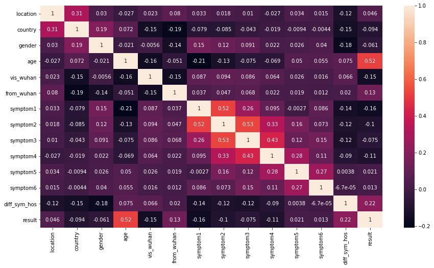

```python
correlation_matrix = df.corr()
plt.figure(figsize=(15,8))
sns.heatmap(correlation_matrix,  annot=True)
plt.show()
```

# Observing Correlation Matrix

After obersving the correlation matrix, it's obvious that all features should not be treated the same, *adding some weight* **"importance"** to some of the features will improve the classifiers results, in the code below we adjust of the weights of every feature and we add an epsilon in case a feature recieves a weight of zero.

```python
importance = correlation_matrix['result'].drop('result')
importance = abs(importance)
importance = (importance - importance.min(axis=0)) / (importance.max(axis=0) - importance.min(axis=0))
importance += 0.00001 # Epsilon.
display(importance)
```

```
location        0.066427
country         0.162402
gender          0.096695
age             1.000010
vis_wuhan       0.275255
from_wuhan      0.229843
symptom1        0.298981
symptom2        0.179978
symptom3        0.123654
symptom4        0.190834
symptom5        0.015528
symptom6        0.000010
diff_sym_hos    0.410635
Name: result, dtype: float64
```

# Visualizing Each Feature Alone

### Obersving the features is important because you may decide to drop or to encode some of the features depending on what you see.

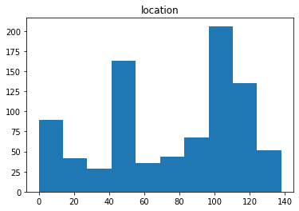

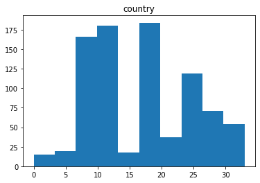

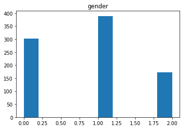

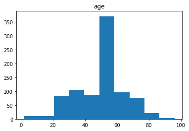

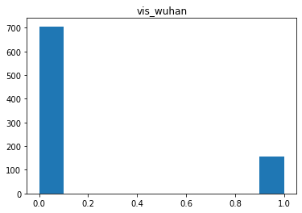

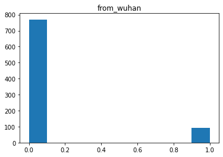

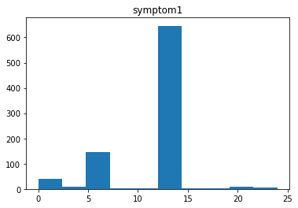

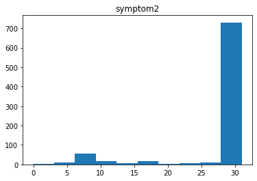

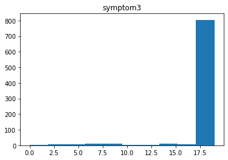

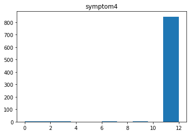

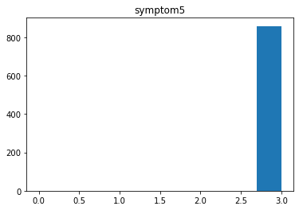

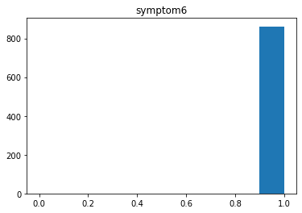

[2 more figures not shown]

```python
for column in df:
    plt.hist(df[column])
    plt.title(column)
    plt.show()
```

# Observing the features

### Dropping Features

We can notice that **symptom 5 and symptom 6** have almost constant values, which means that there is no variance in these features, and keeping them will impact your classifiers negatively therefore it's logical to *drop the 2 features*.

### Removing outliers

Looking into the data we can find also that **"diff_sym_hos"** has some *outliers* that needs to be removed to prevent any negative impact on the classifiers notice a *difference between noise and outliers*, noise acts as an incorrectly placed data while outliers are data samples that shouldn't exist in this data, aka they belong somewhere else.

### One-hot Encoding

Why use **one-hot enconding** to code the data? The basic idea is that a feature value indicates an importance, as if we observe a very low number of minerals in someone bones this is a bigger indicator of the weakness of his bones, likewise if another person bones are high in minerals this indicates that this poerson has healthy bones. However some of the features change in value, may not give any indications, as in when observing the location and the country? is the value of the location or the value of the country indicate anything? probably not, *so it's a good idea to encode this features so that the difference in value doesn't have an effect anymore.*

```python
# Remove Symptom5 and Symptom6.
df.drop("symptom5", axis=1, inplace=True)
df.drop("symptom6", axis=1, inplace=True)

# Remove 2 outliers in diff_sym_hos.
df = df[df['diff_sym_hos'] >= 0]

# Make location,country one-hot.
def make_one_hot(df, col):
    one_hot = pd.get_dummies(df[col]).add_prefix(col+"-")
    return df.drop(col, axis=1).join(one_hot)

df = make_one_hot(df, "location")
df = make_one_hot(df, "country")
# df = make_one_hot(df, "gender")
print(list(df.columns))

df2 = df
df2["result"] = df["result"]
df = df2
df.dropna(inplace=True) # Removes rows and columns with Null/NaN values.
display(df)
```

```
['gender', 'age', 'vis_wuhan', 'from_wuhan', 'symptom1', 'symptom2', 'symptom3', 'symptom4', 'diff_sym_hos', 'result', 'location-0', 'location-1', 'location-2', 'location-3', 'location-4', 'location-5', 'location-6', 'location-7', 'location-8', 'location-9', 'location-10', 'location-11', 'location-1…
```

|  | gender | age | vis_wuhan | from_wuhan | symptom1 | symptom2 | symptom3 | symptom4 | diff_sym_hos | result | ... | country-24 | country-25 | country-26 | country-27 | country-28 | country-29 | country-30 | country-31 | country-32 | country-33 |
| --- | --- | --- | --- | --- | --- | --- | --- | --- | --- | --- | --- | --- | --- | --- | --- | --- | --- | --- | --- | --- | --- |
| 0 | 1 | 66.0 | 1 | 0 | 14 | 31 | 19 | 12 | 8 | 1 | ... | 0 | 0 | 0 | 0 | 0 | 0 | 0 | 0 | 0 | 0 |
| 1 | 0 | 56.0 | 0 | 1 | 14 | 31 | 19 | 12 | 0 | 0 | ... | 0 | 0 | 0 | 0 | 0 | 0 | 0 | 0 | 0 | 0 |
| 2 | 1 | 46.0 | 0 | 1 | 14 | 31 | 19 | 12 | 13 | 0 | ... | 0 | 0 | 0 | 0 | 0 | 0 | 0 | 0 | 0 | 0 |
| 3 | 0 | 60.0 | 1 | 0 | 14 | 31 | 19 | 12 | 0 | 0 | ... | 0 | 0 | 0 | 0 | 0 | 0 | 0 | 0 | 0 | 0 |
| 4 | 1 | 58.0 | 0 | 0 | 14 | 31 | 19 | 12 | 0 | 0 | ... | 0 | 0 | 0 | 0 | 0 | 0 | 0 | 0 | 0 | 0 |
| ... | ... | ... | ... | ... | ... | ... | ... | ... | ... | ... | ... | ... | ... | ... | ... | ... | ... | ... | ... | ... | ... |
| 858 | 2 | 24.0 | 0 | 0 | 14 | 31 | 19 | 12 | 0 | 1 | ... | 0 | 0 | 0 | 0 | 0 | 0 | 0 | 0 | 0 | 0 |
| 859 | 2 | 35.0 | 0 | 0 | 14 | 31 | 19 | 12 | 0 | 0 | ... | 0 | 0 | 0 | 0 | 0 | 0 | 0 | 0 | 0 | 0 |
| 860 | 1 | 49.4 | 0 | 0 | 14 | 31 | 19 | 12 | 0 | 0 | ... | 0 | 0 | 0 | 0 | 0 | 0 | 0 | 0 | 0 | 0 |
| 861 | 1 | 49.4 | 0 | 0 | 14 | 31 | 19 | 12 | 0 | 0 | ... | 0 | 0 | 0 | 0 | 0 | 0 | 0 | 0 | 0 | 0 |
| 862 | 1 | 70.0 | 0 | 0 | 14 | 31 | 19 | 12 | 0 | 0 | ... | 0 | 0 | 0 | 1 | 0 | 0 | 0 | 0 | 0 | 0 |

861 rows × 183 columns

## Note Different Scaling Techniques

```
df2 = pd.DataFrame(MinMaxScaler().fit_transform(df), columns=df.columns)
df2 = pd.DataFrame(PowerTransformer().fit_transform(df), columns=df.columns)
df2 = pd.DataFrame(StandardScaler().fit_transform(df), columns=df.columns)
df2 = pd.DataFrame(QuantileTransformer().fit_transform(df), columns=df.columns)
```

MinMaxScaler and StandardScaler are two of the most popular scalers they are used when dealing with *Continous and Numerical Data.*  
Algorithms that use weighted sum input like *regression* and distance measures like **KNN** works better with continous numerical data.

### Normalization and Standardization

They are two of the most popular techniques for scaling numerical data, normalization scales inputs separately in 0 to 1 ranges, while standardization subtracts the mean *centering* then divided by the standard deviation by this we get a mean of zero and sd of 1.

### MinMaxScaler

It's a normalization technique that by default will put the data between values of zeros and ones, using MinMaxScaler as a normalization method will preseve the data shape and give all each features equal scale of values thus cancelling effect of feature with large values, and now we can add to the features we preseve as important a weight by ourselves.

### StandardScaler

Standard scaler is a standardization techniques it works best wit data that follows a normal distribution, and when the data has negative values; which is not the case in the data we are using. *"Note we also previously tested the StandardScaler and found out that it performed worse than the MinMaxScaler"*

```python
X = df.drop("result", axis=1) # All Data Except Output.
X = pd.DataFrame(MinMaxScaler().fit_transform(X), columns=X.columns)
y = df["result"] # Output Column.

# Applying weights based on the previosuly calculated importance.
weight_cols = ['age', 'vis_wuhan', 'from_wuhan', 'symptom1', 'symptom2', 'symptom3', 'symptom4', 'diff_sym_hos']
X /= 2
X[weight_cols] *= importance[weight_cols]*4
display(X)
```

|  | gender | age | vis_wuhan | from_wuhan | symptom1 | symptom2 | symptom3 | symptom4 | diff_sym_hos | location-0 | ... | country-24 | country-25 | country-26 | country-27 | country-28 | country-29 | country-30 | country-31 | country-32 | country-33 |
| --- | --- | --- | --- | --- | --- | --- | --- | --- | --- | --- | --- | --- | --- | --- | --- | --- | --- | --- | --- | --- | --- |
| 0 | 0.25 | 1.361716 | 0.550509 | 0.000000 | 0.348811 | 0.359956 | 0.247308 | 0.381668 | 0.438011 | 0.0 | ... | 0.0 | 0.0 | 0.0 | 0.0 | 0.0 | 0.0 | 0.0 | 0.0 | 0.0 | 0.0 |
| 1 | 0.00 | 1.148948 | 0.000000 | 0.459685 | 0.348811 | 0.359956 | 0.247308 | 0.381668 | 0.000000 | 0.0 | ... | 0.0 | 0.0 | 0.0 | 0.0 | 0.0 | 0.0 | 0.0 | 0.0 | 0.0 | 0.0 |
| 2 | 0.25 | 0.936180 | 0.000000 | 0.459685 | 0.348811 | 0.359956 | 0.247308 | 0.381668 | 0.711767 | 0.0 | ... | 0.0 | 0.0 | 0.0 | 0.0 | 0.0 | 0.0 | 0.0 | 0.0 | 0.0 | 0.0 |
| 3 | 0.00 | 1.234055 | 0.550509 | 0.000000 | 0.348811 | 0.359956 | 0.247308 | 0.381668 | 0.000000 | 0.0 | ... | 0.0 | 0.0 | 0.0 | 0.0 | 0.0 | 0.0 | 0.0 | 0.0 | 0.0 | 0.0 |
| 4 | 0.25 | 1.191501 | 0.000000 | 0.000000 | 0.348811 | 0.359956 | 0.247308 | 0.381668 | 0.000000 | 0.0 | ... | 0.0 | 0.0 | 0.0 | 0.0 | 0.0 | 0.0 | 0.0 | 0.0 | 0.0 | 0.0 |
| ... | ... | ... | ... | ... | ... | ... | ... | ... | ... | ... | ... | ... | ... | ... | ... | ... | ... | ... | ... | ... | ... |
| 856 | 0.50 | 0.468090 | 0.000000 | 0.000000 | 0.348811 | 0.359956 | 0.247308 | 0.381668 | 0.000000 | 0.0 | ... | 0.0 | 0.0 | 0.0 | 0.0 | 0.0 | 0.0 | 0.0 | 0.0 | 0.0 | 0.0 |
| 857 | 0.50 | 0.702135 | 0.000000 | 0.000000 | 0.348811 | 0.359956 | 0.247308 | 0.381668 | 0.000000 | 0.5 | ... | 0.0 | 0.0 | 0.0 | 0.0 | 0.0 | 0.0 | 0.0 | 0.0 | 0.0 | 0.0 |
| 858 | 0.25 | 1.008521 | 0.000000 | 0.000000 | 0.348811 | 0.359956 | 0.247308 | 0.381668 | 0.000000 | 0.0 | ... | 0.0 | 0.0 | 0.0 | 0.0 | 0.0 | 0.0 | 0.0 | 0.0 | 0.0 | 0.0 |
| 859 | 0.25 | 1.008521 | 0.000000 | 0.000000 | 0.348811 | 0.359956 | 0.247308 | 0.381668 | 0.000000 | 0.0 | ... | 0.0 | 0.0 | 0.0 | 0.0 | 0.0 | 0.0 | 0.0 | 0.0 | 0.0 | 0.0 |
| 860 | 0.25 | 1.446823 | 0.000000 | 0.000000 | 0.348811 | 0.359956 | 0.247308 | 0.381668 | 0.000000 | 0.0 | ... | 0.0 | 0.0 | 0.0 | 0.5 | 0.0 | 0.0 | 0.0 | 0.0 | 0.0 | 0.0 |

861 rows × 182 columns

## Data Sampling and Random Sampling

### Train Test Split

In Supervised Machine Learning, you usually need to split your into three samples one for training, one for validation and adjusting hyper parameters and the last one is for testing ; In the code below you can find out that we are splitting the data into two, training and sampling, this because when you use validation methods like stratified kfolds later on, the part of the validation will get managed.. notice that we leave 20% of the data for testing.  
why stratify? `stratify=y` parameter will preserve the proportion of target as in original dataset, in the train and test datasets as well.

### RandomOverSampler

*Applying re-sampling strategies to obtain a more balanced data distribution is an effective solution to the imbalance problem.*`RandomOverSampler(random_state=42)`Resampling basically creates a new version of the training dataset with a different distribution, we chose random resampling since it's one of the simplest stratigies. *RandomOverSampling basically duplicates examples in minority classes ;*This technique is useful when trying to achieve a good distribution of the data, and when dealing with algorithms that are affected by skewed distributions, *it can also be effective for models like **decision trees and support vector machines.*** as they seek in splitting the data, and it's also useful for models that iteratively learn coefficients.

```python
X, X_test, y, y_test = train_test_split(X, y, test_size=0.2, stratify=y)
ros = RandomOverSampler(random_state=42)
X, y = ros.fit_resample(X, y)
```

# Metric Functions

### Metric Calculation Helper Function

In the code below you can notice the following function: `calc_metrics(y_true, y_pred, y_pred_proba=None, debug=True)`We use this function to calculate for us the desired metrics; but what are our desired metrics and what does each one indicate?

- **Accuracy:** It's simply the number of correct predictions divided by the total number of predictions; It can be calculated by the sum of the predicted true positives and true negtives over the total.
- **Precision:** It Quantifies the number of positive class prediction that actually does belong to the positive class ; It's the ratio between the true positives and the sum of true positives and false positives, *In other words it's the ability of the classifier not to label a negative sample as positive which is very important in medical industry.*
- **Recall:** It's formula is the number of true positives divided by the sum of true positives and false negatives, notice that we usually care more about the false positive especially in the medical industry thus in such fields we prefer to have a higher precision; *Unlike prediction it quantifies the number of correct positive predictions out of all positive predictions that has been made.*
- **f1score:** It's the mean of precision and recall, it takes into account both the FP and FN ; however it's different from accuracy ; *when there is a difference in the cost of false positive and false negatives as in medical field then the f1 score will be more important than the accuracy.*

### AUC-ROC Curve

- They are useful metics for measuring the perfomance of classification models.
- **ROC** is a probability curve ; It's better used when having *equal number of observation of for each class*; however when using an *ROC curve with imbalanced data it might be very deceptive* and lead to wrong interpretations.
- **AUC** represents the degree of separability ; aka tells us how capable is the model of distingushing between classes.

```python
def calc_metrics(y_true, y_pred, y_pred_proba=None, debug=True):
    zero_division="warn" if debug else 0

    accuracy = sklearn.metrics.accuracy_score(y_true, y_pred)
    percision = sklearn.metrics.precision_score(y_true, y_pred, zero_division=zero_division)
    recall = sklearn.metrics.recall_score(y_true, y_pred, zero_division=zero_division)
    f1score = sklearn.metrics.f1_score(y_true, y_pred, zero_division=zero_division)

    auc = None
    if y_pred_proba is not None:
        y_pred_proba = y_pred_proba[::,1]
        fpr, tpr, _ = sklearn.metrics.roc_curve(y_true,  y_pred_proba)
        auc = sklearn.metrics.roc_auc_score(y_true, y_pred_proba)

        if debug:
            pyplot.plot(fpr,tpr)
            pyplot.title("ROC Curve")
            pyplot.show()

    ret = {"Accuracy":accuracy, "Percision":percision, "Recall":recall, "F1 Score":f1score, "AUC":auc}
    if debug:
        for key, value in ret.items():
            print(f"{key} = {value}")
        print("\n",sklearn.metrics.classification_report(y_true, y_pred))

    return ret
```

# k-Fold Cross-Validation

### Cross Validation

Cross-validation *is a method used to evaluate machine learning models by resampling on a limited data set.* The k in k-Fold represents the number of samples in which our data will be divided into; Cross-validation is a popular technique in Machine learning used for estimating how the model will behave on unseen data.

### The Choice Of K

The choice of k is very important because a *bad one may lead to a mis-representive data*; so how to choose the k? there are several techniques for choosing k, but by practice it turns out *choosing k as 5 or 10 is good to go.*

### Repeated K-fold

In repeated k-fold we repeat the procedure for the given n number of times, to ensure that data samples don't repeat; the data set is shuffled before each repetition. But why use repeated k-fold? We use repeated k-fold because it prooves the estimate performance of the machine learning model as *it reports the mean performance accross all folds and repeats this helps reduces the noise from the original estimate model.*

### Stratified K-fold

Stratified K-fold *is basically an improved version of the K-fold* it ensures that each fold of the dataset has the same proportions of the types inside the label class.*So we deduce that the major difference is that it uses stratified sampling instead of random sampling.*

```python
def calc_metrics_kfolds(classifier, X, y, debug=True):
    zero_division="warn" if debug else 0

    cv = RepeatedStratifiedKFold(n_splits=5, n_repeats=3, random_state=42)

    metrics = cross_validate(classifier, X.values, y.values, scoring=('accuracy','precision','recall','f1','roc_auc'), cv=cv, n_jobs=-1)
    accuracy = np.mean(metrics['test_accuracy'])
    precision = np.mean(metrics['test_precision'])
    recall = np.mean(metrics['test_recall'])
    f1score = np.mean(metrics['test_f1'])
    auc = np.mean(metrics['test_roc_auc'])

    ret = {"Accuracy":accuracy, "Precision":precision, "Recall":recall, "F1 Score":f1score, "AUC":auc}
    if debug:
        for key, value in ret.items():
            print(f"{key} = {value}")
        # print(metrics)

    return ret
```

# KNN

## Find the best KNN classifier

Hyberparemeter turning for the KNN model is done by looping from n=1 to n=$\sqrt{m}$, where m is the number of data points. For each N, a KNN classifier is created and cross-validated with the training data. Finally the metrics of each model are stored in the `accuracy`, `percision`, `recall`, `f1_score` and `auc` lists for further analysis.

```python
accuracy, percision, recall, f1_score, auc = [],[],[],[],[]
maxn = int(sqrt(len(X)))
for n in range(1,maxn):
    knn_classifier = KNeighborsClassifier(n_neighbors=n)

    metrics = calc_metrics_kfolds(knn_classifier, X, y, debug=False)

    accuracy.append(metrics["Accuracy"])
    percision.append(metrics["Precision"])
    recall.append(metrics["Recall"])
    f1_score.append(metrics["F1 Score"])
    auc.append(metrics["AUC"])
```

## Plotting metrics for the KNN model

All the metrics are plotted in a single graph, so that the optimal n can be chosen for the final model.

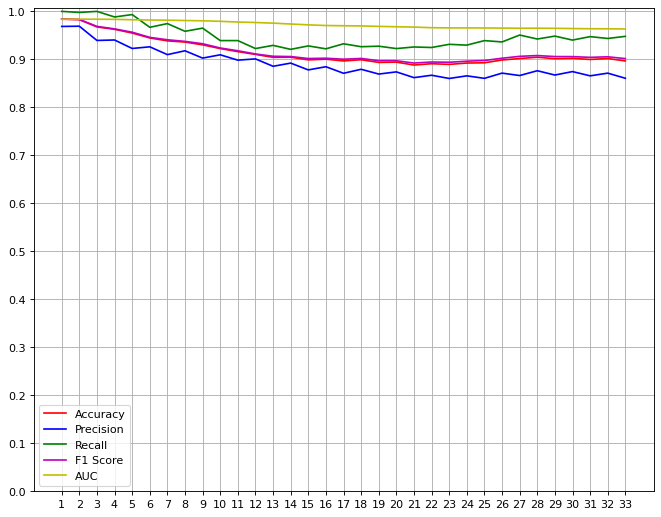

```python
x_axis = np.arange(1, maxn, 1)
pyplot.figure(figsize=(10, 8), dpi=80)
pyplot.plot(x_axis, accuracy, 'r-', label="Accuracy")
pyplot.plot(x_axis, percision, 'b-', label="Precision")
pyplot.plot(x_axis, recall, 'g-', label="Recall")
pyplot.plot(x_axis, f1_score, 'm-', label="F1 Score")
pyplot.plot(x_axis, auc, 'y-', label="AUC")
pyplot.xticks(x_axis)
pyplot.yticks(np.arange(0, 1.1, 0.1))
pyplot.legend()
pyplot.grid()
pyplot.show()
```

## Cross validation results

The optimal KNN model is created and cross validated one last time with the training data.

```python
KNN_classifier = KNeighborsClassifier(n_neighbors=1)
metrics = calc_metrics_kfolds(KNN_classifier, X, y, debug=True)
```

```
Accuracy = 0.983659520516367
Precision = 0.9686017281891743
Recall = 1.0
F1 Score = 0.9839914308484808
AUC = 0.9836501377410468
```

# Logistic Regression

Hyperparemeter turning for the Logistic Regression model is done using sklearn's built-in `GridSearchCV`. `RepeatedStratifiedKFold` is used here too instead of normal K-Fold for two main reasons:

1. Repeated: To increase the accuracy of the estimate received by the `GridSearchCV`, thus improving the hyperparameter search process.
2. Stratified: To make sure the data point classes are balanced in the folds, because we previously used the `RandomOverSampler` which might still not result in the data being perfectly balanced.

```python
LR_classifier = LogisticRegression(max_iter=1000)

# print(np.logspace(-2.5,3,10))
LR_parameters={"C":np.logspace(-2.5,3,10), "penalty":["l1","l2","elasticnet","none"]}
cv = RepeatedStratifiedKFold(n_splits=5, n_repeats=3, random_state=42)
LR_search=GridSearchCV(estimator = LR_classifier, param_grid = LR_parameters, n_jobs=-1,\
                       cv=cv, scoring=('accuracy','precision','recall','f1','roc_auc'), refit='recall')
LR_search.fit(X,y)
print("Tuned Hyperparameters: ", LR_search.best_params_)
print("Tuned Estimator: ", LR_search.best_estimator_)
```

```
Tuned Hyperparameters:  {'C': 0.0031622776601683794, 'penalty': 'none'}
Tuned Estimator:  LogisticRegression(C=0.0031622776601683794, max_iter=1000, penalty='none')
```

## Cross validation results

The optimal Logistic Regression model is created and cross validated one last time with the training data.

```python
LR_classifier = LogisticRegression(C=LR_search.best_params_['C'], penalty=LR_search.best_params_['penalty'], max_iter=1000)
metrics = calc_metrics_kfolds(LR_classifier, X, y, debug=True)
```

```
Accuracy = 0.9905878284923928
Precision = 0.9817052647337642
Recall = 1.0
F1 Score = 0.9907256095613154
AUC = 0.9973147382920111
```

# Gaussian Naive Bayes

The Naive Bayes model fails quickly in the case of input data correlation. For that specific reason, not all of the columns have been chosen. Most of the symtom columns have high correlation, so only `symptom1` and `symptom4` were chosen because:

- The correlation `symptom1` and `symptom4` is not very high
- The correlation between `symptom1` and the `result` is good
- The correlation between `symptom4` and the `result` is good Most of the other columns were discarded, and only the ones with highest correlation with the result were chosen to be included in the model's training and testing.

Those choices were all aided by the correlation matrix created earlier.

```python
NB_classifier = GaussianNB()
NB_cols = ['age', 'vis_wuhan', 'from_wuhan', 'symptom1', 'symptom4', 'diff_sym_hos']
X2 = X[NB_cols]

NB_parameters={'var_smoothing': np.logspace(0,-9, num=100)}
cv = RepeatedStratifiedKFold(n_splits=5, n_repeats=3)
NB_search=GridSearchCV(estimator = NB_classifier, param_grid = NB_parameters, n_jobs=-1, verbose=-1, \
                       cv=cv, scoring=('accuracy','precision','recall','f1','roc_auc'), refit='recall')
NB_search.fit(X2,y)
print("Tuned Hyperparameters: ", NB_search.best_params_)
print("Tuned Estimator: ", NB_search.best_estimator_)
```

```
Tuned Hyperparameters:  {'var_smoothing': 0.01}
Tuned Estimator:  GaussianNB(var_smoothing=0.01)
```

## Cross validation results

The optimal Naive Bayes model is created and cross validated one last time with the training data.

```python
NB_classifier = GaussianNB(var_smoothing=NB_search.best_params_['var_smoothing'])
metrics = calc_metrics_kfolds(NB_classifier, X2, y, debug=True)
```

```
Accuracy = 0.8698755186721991
Precision = 0.8427213464398297
Recall = 0.9108356290174471
F1 Score = 0.8750722864930791
AUC = 0.9018696051423326
```

# Decision Trees

The decision tree model is also trained using `GridSearchCV` and the hyperparameters to search through are:

- The split criterion (gini or entropy)
- The max depth of the tree

```python
DT_classifier = DecisionTreeClassifier()

DT_parameters = {'criterion':['gini','entropy'],'max_depth':[3, 4, 5, 6, 7, 8, 9, 10, 11, 12, 13, 14, 15, 16]}

cv = RepeatedStratifiedKFold(n_splits=5, n_repeats=3, random_state=42)
DT_search = GridSearchCV(estimator = DT_classifier, param_grid = DT_parameters, cv=cv,
                         scoring=('accuracy','precision','recall','f1','roc_auc'), refit='recall')

DT_search.fit(X,y)
print("Tuned Hyperparameters: ", DT_search.best_params_)
print("Tuned Estimator: ", DT_search.best_estimator_)
```

```
Tuned Hyperparameters:  {'criterion': 'gini', 'max_depth': 5}
Tuned Estimator:  DecisionTreeClassifier(max_depth=5)
```

## Cross validation results

```python
DT_classifier = DecisionTreeClassifier(criterion=DT_search.best_params_['criterion'], max_depth=DT_search.best_params_['max_depth'])
metrics = calc_metrics_kfolds(DT_classifier, X, y, debug=True)
```

```
Accuracy = 0.977579529737206
Precision = 0.9583907632495221
Recall = 0.9988980716253444
F1 Score = 0.9781473751229244
AUC = 0.9753795339761248
```

## Decision Tree Visualization

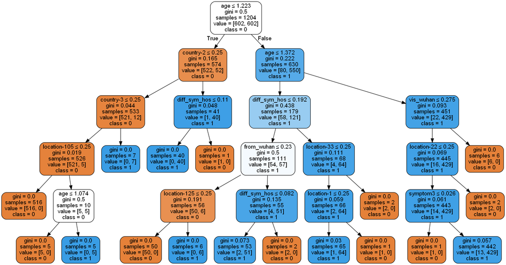

```python
DT_classifier.fit(X.values, y.values)
dot_data = StringIO()
feature_cols = X.columns
export_graphviz(DT_classifier, out_file = dot_data, rounded = True, filled = True, special_characters = True, feature_names = feature_cols, class_names = ["0", "1"])
graph = pydotplus.graph_from_dot_data(dot_data.getvalue())
graph.write_png("DT Corona.png")
Image(graph.create_png())
```

# Support Vector Machines

## SVM Kernels

- The linear kernel is mostly preferred for text classification problems as it performs well for large datasets.
- Rbf kernel is kind of Gaussian kernel which tends to give good results on data that got no additional informations and in projects with high dimensional data, the Rbf finally linearly seprates it..
- Polynomial kernels give good results for problems when all the training data is normalized.

```python
SVM_classifier = SVC()

SVM_parameters = [{'C': [0.001, 0.01, 0.1, 1, 3, 5, 10, 15, 20],'gamma':[0.001, 0.01, 0.1, 1, 3, 5, 10, 15, 20], 'degree':[2, 3, 4, 5],\
                'kernel': ['linear', 'rbf', 'poly']}]

cv = RepeatedStratifiedKFold(n_splits=5, random_state=42)
SVM_search = GridSearchCV(SVM_classifier, SVM_parameters, cv=cv, n_jobs=-1, \
                          scoring=('accuracy','precision','recall'), refit = 'recall')

SVM_search.fit(X,y)
print("Tuned Hyperparameters: ", SVM_search.best_params_)
print("Tuned Estimator: ", SVM_search.best_estimator_)
```

```
Tuned Hyperparameters:  {'C': 0.001, 'degree': 3, 'gamma': 10, 'kernel': 'poly'}
Tuned Estimator:  SVC(C=0.001, gamma=10, kernel='poly')
```

## Cross Validation Results

```python
SVM_classifier = SVC(C=SVM_search.best_params_['C'], gamma=SVM_search.best_params_['gamma'], \
                     degree=SVM_search.best_params_['degree'], kernel=SVM_search.best_params_['kernel'], \
                     probability=True)
metrics = calc_metrics_kfolds(SVM_classifier, X, y, debug=True)
```

```
Accuracy = 0.9831143384047948
Precision = 0.967770868144306
Recall = 1.0
F1 Score = 0.9835197363869774
AUC = 0.9987037037037038
```

# Testing The Models

Note that in testing, we will be using the X_test, y_test instead of the training data, You can never obtain all the world data so that the training is enough, thus the final purpose of Machine Learning Alogirthms is to achieve a good testing results, testing is usually done on a data that the model has never seen before, by this way *We can obtain an idea about how our model will behave in upon deployment life.*

## KNN

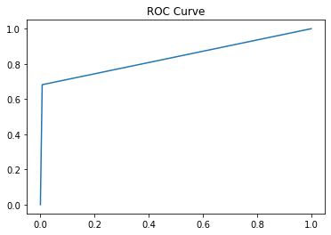

```
Accuracy = 0.953757225433526
Percision = 0.9375
Recall = 0.6818181818181818
F1 Score = 0.7894736842105263
AUC = 0.8375978326309451

               precision    recall  f1-score   support

           0       0.96      0.99      0.97       151
           1       0.94      0.68      0.79        22

    accuracy                           0.95       173
   macro avg       0.95      0.84      0.88       173
weighted avg       0.95      0.95      0.95       173
```

```python
KNN_classifier.fit(X.values, y.values)
p_test = KNN_classifier.predict(X_test.values)
p_test_proba = KNN_classifier.predict_proba(X_test.values)
metrics = calc_metrics(y_test, p_test, p_test_proba)
```

# Logistic Regression

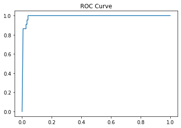

```
Accuracy = 0.9710982658959537
Percision = 0.9047619047619048
Recall = 0.8636363636363636
F1 Score = 0.8837209302325582
AUC = 0.99262492474413

               precision    recall  f1-score   support

           0       0.98      0.99      0.98       151
           1       0.90      0.86      0.88        22

    accuracy                           0.97       173
   macro avg       0.94      0.93      0.93       173
weighted avg       0.97      0.97      0.97       173
```

```python
LR_classifier.fit(X.values, y.values)
p_test = LR_classifier.predict(X_test.values)
p_test_proba = LR_classifier.predict_proba(X_test.values)
metrics = calc_metrics(y_test, p_test, p_test_proba)
```

# Naive Bayes

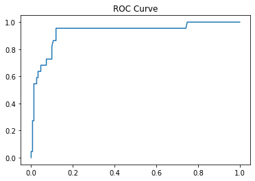

```
Accuracy = 0.8901734104046243
Percision = 0.5384615384615384
Recall = 0.9545454545454546
F1 Score = 0.6885245901639344
AUC = 0.9283564118001204

               precision    recall  f1-score   support

           0       0.99      0.88      0.93       151
           1       0.54      0.95      0.69        22

    accuracy                           0.89       173
   macro avg       0.77      0.92      0.81       173
weighted avg       0.93      0.89      0.90       173
```

```python
NB_classifier.fit(X[NB_cols].values, y.values)
p_test = NB_classifier.predict(X_test[NB_cols].values)
p_test_proba = NB_classifier.predict_proba(X_test[NB_cols].values)
metrics = calc_metrics(y_test, p_test, p_test_proba)
```

# Decision Trees

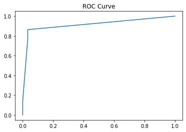

```
Accuracy = 0.953757225433526
Percision = 0.7916666666666666
Recall = 0.8636363636363636
F1 Score = 0.8260869565217391
AUC = 0.9161649608669478

               precision    recall  f1-score   support

           0       0.98      0.97      0.97       151
           1       0.79      0.86      0.83        22

    accuracy                           0.95       173
   macro avg       0.89      0.92      0.90       173
weighted avg       0.96      0.95      0.95       173
```

```python
DT_classifier.fit(X.values, y.values)
p_test = DT_classifier.predict(X_test.values)
p_test_proba = DT_classifier.predict_proba(X_test.values)
metrics = calc_metrics(y_test, p_test, p_test_proba)
```

# Support Vector Machines

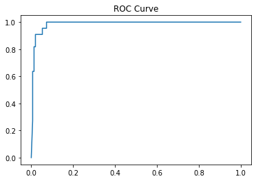

```
Accuracy = 0.9653179190751445
Percision = 0.8333333333333334
Recall = 0.9090909090909091
F1 Score = 0.8695652173913043
AUC = 0.9867549668874172

               precision    recall  f1-score   support

           0       0.99      0.97      0.98       151
           1       0.83      0.91      0.87        22

    accuracy                           0.97       173
   macro avg       0.91      0.94      0.92       173
weighted avg       0.97      0.97      0.97       173
```

```python
SVM_classifier.fit(X.values, y.values)
p_test = SVM_classifier.predict(X_test.values)
p_test_proba = SVM_classifier.predict_proba(X_test.values)
metrics = calc_metrics(y_test, p_test, p_test_proba)
```

# Support Material

- [Train Test Split](https://realpython.com/train-test-split-python-data/)
- [One Hot Encoding](https://machinelearningmastery.com/why-one-hot-encode-data-in-machine-learning/)
- [Dataframe correlation](https://www.geeksforgeeks.org/python-pandas-dataframe-corr/)
- Scaling Techniques
- [Random Sampling](https://machinelearningmastery.com/random-oversampling-and-undersampling-for-imbalanced-classification/)
- [The Metrics](https://machinelearningmastery.com/precision-recall-and-f-measure-for-imbalanced-classification/#:~:text=Precision%20quantifies%20the%20number%20of,and%20recall%20in%20one%20number.)
- [ROC-AUC Curve](https://machinelearningmastery.com/roc-curves-and-precision-recall-curves-for-classification-in-python/)
- [K-Fold Cross Validation](https://machinelearningmastery.com/k-fold-cross-validation/)
- [Stratified K-fold](https://www.geeksforgeeks.org/stratified-k-fold-cross-validation/)
- [Decision Trees](https://scikit-learn.org/stable/modules/tree.html)
- [Decision Tree with Grid Search](https://www.projectpro.io/recipes/optimize-hyper-parameters-of-decisiontree-model-using-grid-search-in-python)
- [Support Vector Machines Parameters](https://scikit-learn.org/stable/modules/generated/sklearn.svm.SVC.html)
- [Grid Search For Support Vector Machines](https://aneesha.medium.com/svm-parameter-tuning-in-scikit-learn-using-gridsearchcv-2413c02125a0)
- [Link 2: Grid Search For Support Vector Machines](https://www.codespeedy.com/svm-parameter-tuning-using-gridsearchcv-in-python/)
- [Link 2:Support Vector Machines Kernels](https://dataaspirant.com/svm-kernels/)
- [A Helpful Machine Learning Youtube Channel!](https://www.youtube.com/c/joshstarmer)

### That's All Folks!

**We hope that our code, serves your learning process, and that our documentation makes everything clear for you!**